# act_report

## Report and Insight

> This report communicates the insights drawn from the WeRateDogs data wrangling project.

> The insights drawn will be communicated also through visualization(s) that will be produced from the WeRateDogs wrangled data. The insights and visualizations that will be diplayed in this report will focused majorly on the doy_stages variable.

> The four major dog stages indicated in the data set are; doggo, floofer, pupper, puppo and None for dogs with no specific stage. whwere their where dogs which fell into more than one dog stage. this we would discussed in details in this report.

### Summary of Data Cleaning Procedure carried out in cleaning the WeRateDogs data set

> The p1, p2 and jpg_url columns from the image_predictions.tsv were merged to the twitter_archive_enhanced data set on tweet_id. The user_id variable in the tweets_df data set was renamed to tweet_id to ease the merging of retweet_count and favorite_count from the tweets_id data set to the twitter_archive_enhanced data set. The doggo, floofer, pupper and puppo variable was melt into one variable called dog_stage. The data type of variables like timestamp, retweeted_status_timestamp where change from object to datetime. the in_reply_to_status_id, tweets_id, retweeted_status_user_id and in_reply_to_user_id where change to data type object using the .apply() method. This is because they are not numeric and are not needed to perform any calculations. The retweeted_status_id data was extracted from the expanded_urls variable using regular expresion. The rating_numerator and reating_denominator data were extracted from the text variable using regular expression regrex. he iloc() function was also used to fill the correct dog names in the name variable. the appropriate dog name was obtained from the text variable in the twitter_archive_enhanced.csv file and the cleaned data was stored to a csv file with name twitter_archive_master.csv

### Distribution of dog stages

```
pupper            210
doggo              67
puppo              23
doggo, pupper      11
floofer             7
doggo, puppo        1
doggo, floofer      1
Name: dog_stage, dtype: int64
```

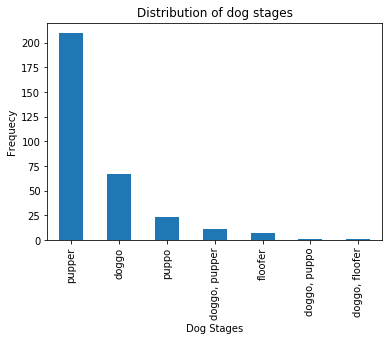

### Distribution of dog rating numerator by dog stages

```
dog_stage
doggo             11.970149
doggo, floofer    11.000000
doggo, pupper     11.181818
doggo, puppo      13.000000
floofer           12.000000
pupper            10.677476
puppo             12.000000
Name: extractedrating_numerator, dtype: float64
```

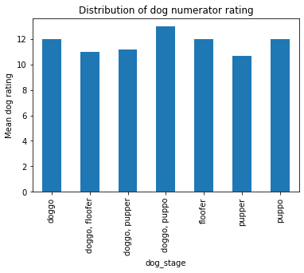

### Distribution of dog rating denominator by dog stages

```
dog_stage
doggo             10
doggo, floofer    10
doggo, pupper     10
doggo, puppo      10
floofer           10
pupper            10
puppo             10
Name: extractedrating_denominator, dtype: int64
```

> The Distribution above show the dog rating denominator by dog stages. The insight draw from this distribution shows that all dog stage have the rating denominator. The graph below displays this distribution.

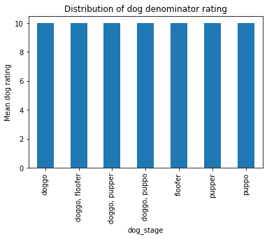

### Distribution of retweeted count by dog stages

```
dog_stage
doggo              7901.552239
doggo, floofer     3433.000000
doggo, pupper      5262.909091
doggo, puppo      19196.000000
floofer            4968.714286
pupper             2468.209524
puppo              6431.434783
Name: retweet_count, dtype: float64
```

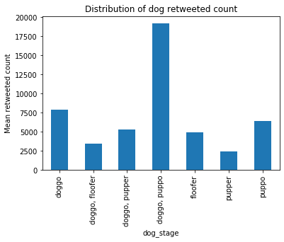